# Assignment 1

Francesco Caporali, Isabel Muzio

20 November 2022

# Question 1: The Galenshore distribution

## Point a.

$Y | \theta \sim \operatorname{Galenshore}\left(a, \theta\right)$ is such that $p(y|\theta)$ is a density in the exponential family indeed
$$p(y | \theta) =
\frac{2}{\Gamma(a)}\theta^{2a}y^{2a - 1}e^{-\theta^2y^2}1_{\left\{y >
0\right\}}, \theta > 0, a > 0.$$
Then definining $\phi \stackrel{\text{def}}{=}\theta^2$ one has
$$p(y | \phi) = h(y)c(\phi)e^{\phi t(y)}
\text{ with } h(y) = \frac{2 y^{2a - 1}}{\Gamma(a)}1_{\left\{y >
0\right\}}, c(\phi) = \phi^a, t(y) = -y^2,$$
hence, by the easy shape of a distribution in the exponential family, we can state that a class of conjugate priors for $p(y | \phi)$ is such that
$$p(\phi) \propto
c(\phi)^{n_0}e^{\phi n_0t_0} = \phi^{a n_0}e^{\phi n_0t_0}.$$
If $\phi$ has density $p(\phi)$ and we want to obtain the density of $\theta = \sqrt{\phi}$ it is sufficient to define the map $f: \mathbb{R}^+ \to \mathbb{R}^+$ such that $f(x) = \sqrt{x}$ and recall that
$$p_{\theta}(\theta) = p_{\phi}(f(\phi)) =
p_{\phi}(f^{-1}(\theta) \left|\frac{d f^{-1}(\theta)}{d
\theta}\right|.$$
Observing that $\left|\frac{d f^{-1}(\theta)}{d \theta}\right| = \left|\frac{d \theta^2}{d \theta}\right| = 2\theta$
$$p(\theta)
\stackrel{\text{def}}{=}p_{\theta}(\theta) = p_{\phi}(\theta^2) 2 \theta
\propto \theta^{2an_0} e^{\theta^2 n_0 t_0} 2 \theta.$$

### Remark

Hence we have
$$an_0 + 1 > 0 \text{ and
} -n_0t_0 > 0.$$
So we can rewrite
$$p(\theta) \propto 2 \theta^{2an_0 + 1} e^{-
\left(\sqrt{-n_0t_0}\right)^2 \theta^2}$$
and recognizing the kernel of a Galenshore distribution we can write explicitly
$$\begin{align*}
p(\theta) & = 2 \theta^{2(an_0 + 1) - 1} e^{-
\left(\sqrt{-n_0t_0}\right)^2 \theta^2} \cdot
\underbrace{\frac{\left(\sqrt{-n_0t_0}\right)^{2(an_0 + 1)}}{\Gamma(an_0
+ 1)}}_{\text{it does not depends on $\theta$}} \underbrace{1_{\theta
> 0}}_{\text{by hypotesis}} = \\
& = \frac{2}{\Gamma(an_0 + 1)}
\left(\sqrt{-n_0t_0}\right)^{2(an_0 + 1)} \theta^{2(an_0 + 1) - 1} e^{-
\left(\sqrt{-n_0t_0}\right)^2 \theta^2} 1_{\theta > 0}
\end{align*}$$
$$\Downarrow$$
$$\theta \sim
\operatorname{Galenshore}\left(an_0 + 1, \sqrt{-n_0t_0}\right).$$
Finally we plot a few of these densities $\operatorname{Galenshore}\left(an_0 + 1, \sqrt{-n_0t_0}\right)$ sampled with the following code:

```r
dgalenshore = function(y, a, theta) {
    (2 / gamma(a)) * theta^(2 * a) * y^(2 * a - 1) * exp(-(theta^2) * y^2)
}

y = seq(0.01, 3.5, length = 1000)
df = rbind(
    data.frame(y = y, gal_y = dgalenshore(y, 2, 1), label = "(2, 1)"),
    data.frame(y = y, gal_y = dgalenshore(y, 3, sqrt(2)), label = "(3, sqrt(2))"),
    data.frame(y = y, gal_y = dgalenshore(y, 3, 2), label = "(3, 2)"),
    data.frame(y = y, gal_y = dgalenshore(y, 5, 2), label = "(5, 2)"),
    data.frame(y = y, gal_y = dgalenshore(y, 4, 3), label = "(4, 3)"),
    data.frame(y = y, gal_y = dgalenshore(y, 4, 4), label = "(4, 4)")
)
```

Then we plot all of them at the same time:

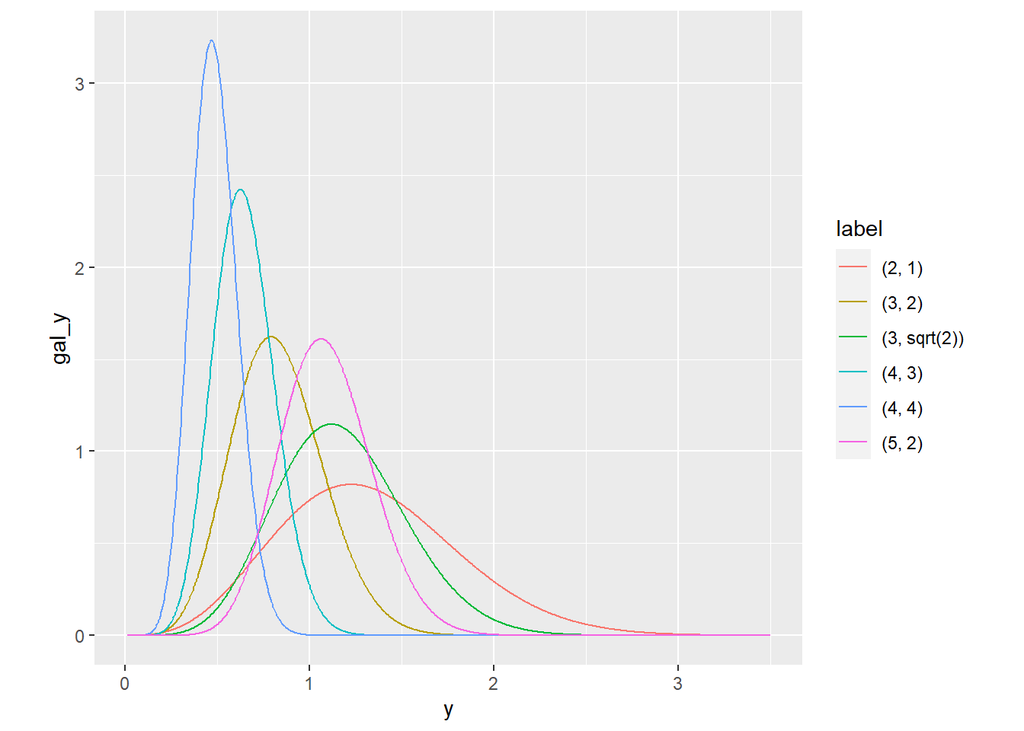

```r
ggplot(df, aes(y, gal_y, group = label, color = label)) +
geom_line() + coord_fixed(ratio = 1)
```

## Point b.

Let’s define $b \stackrel{\text{def}}{=}an_0 + 1$ and $c = \sqrt{-n_0t_0}$ for coinciseness.
Recalling $\theta \sim \operatorname{Galenshore}\left(b, c\right)$ and $Y_i | \theta \sim \operatorname{Galenshore}\left(a, \theta\right), \forall i \in 1:n$ and defining $\operatorname{SS}\left(y_{1:n}\right) \stackrel{\text{def}}{=}\sum_{i = 1}^n y_i^2$ we have
$$\begin{align*}
p(\theta | y_{1:n}) & = p(\theta) p(y_{1:n} | \theta) \propto \\
& \propto (\theta^{2b - 1} e^{-c^2\theta^2}) (\theta^{2na}
e^{-\theta^2\sum_{i = 1}^n y_i^2}) \propto \\
& \propto \theta^{2(an + b) - 1} e^{-(c^2 +
\operatorname{SS}\left(y_{1:n}\right))\theta^2}.
\end{align*}$$
Hence we recognize the kernel of a $\operatorname{Galenshore}\left(an + b, \sqrt{c^2 + \operatorname{SS}\left(y_{1:n}\right)}\right)$
$$\implies \theta | Y_{1:n} \sim
\operatorname{Galenshore}\left(a(n + n_0) + 1,
\sqrt{\operatorname{SS}\left(y_{1:n}\right) -
n_0t_0}\right).$$

## Point c.

$$\begin{align*}
\frac{p(\theta_a | y_{1:n})}{p(\theta_b | y_{1:n})} & = \frac{2
\Gamma(a(n + n_0) + 1)}{\Gamma(a(n + n_0) + 1)
2} \left(\operatorname{SS}\left(y_{1:n}\right) - n_0t_0\right)^{(a(n +
n_0) + 1)(1 - 1)} \left(\frac{\theta_a}{\theta_b}\right)^{2 a(n + n_0) +
1} e^{-\left(\operatorname{SS}\left(y_{1:n}\right) -
n_0t_0\right)\left(\theta_a^2 - \theta_b^2\right)} = \\
& = \left(\frac{\theta_a}{\theta_b}\right)^{2 a(n + n_0) + 1}
e^{-\left(\sum_{i = 1}^n y_i^2 - n_0t_0\right)\left(\theta_a^2 -
\theta_b^2\right)}.
\end{align*}$$
Hence
$$\mathbb{P}\left(\theta \in A | Y_{1:n} =
y_{1:n}\right) = \mathbb{P}\left(\theta \in A | \sum_{i = 1}^n Y_i^2 =
\sum_{i = 1}^n y_i^2\right), \forall A$$
and then, by definition $\operatorname{SS}\left(Y_{1:n}\right) \stackrel{\text{def}}{=}\sum_{i = 1}^n Y_i^2$ is a sufficient statistic.

## Point d.

Recalling that $\theta | Y_{1:n} \sim \operatorname{Galenshore}\left(a(n + n_0) + 1, \sqrt{\operatorname{SS}\left(y_{1:n}\right) - n_0t_0}\right)$ and that if $X \sim \operatorname{Galenshore}\left(a, \theta\right) \implies \mathbb{E}\left[X\right] = \frac{\Gamma\left(a + \frac{1}{2}\right)}{\theta \Gamma(a)}$ we have
$$\mathbb{E}\left[\theta|y_{1:n}\right] =
\frac{\Gamma\left(a(n + n_0) +
\frac{3}{2}\right)}{\left(\sqrt{\operatorname{SS}\left(y_{1:n}\right) -
n_0t_0}\right) \Gamma(a(n + n_0) + 1)}$$

## Point e.

With the usual notation $b \stackrel{\text{def}}{=}an_0 + 1$ and $c \stackrel{\text{def}}{=}\sqrt{-n_0t_0}$:
$$\begin{align*}
p(y_{n + 1} | y_{1:n}) & = \int_0^{\infty} p(y_{n + 1} | \theta)
p(\theta | y_{1:n}) d\theta = \\
& = \int_0^{\infty} \frac{2}{\Gamma(a)} \theta^{2a}y_{n + 1}^{2a
- 1} e^{-\theta^2y_{n + 1}^2} \cdot \frac{2}{\Gamma(an + b)} \left(c^2 +
\operatorname{SS}\left(y_{1:n}\right)\right)^{an + b} \theta^{2(an + b)
- 1} e^{-(c^2 + \operatorname{SS}\left(y_{1:n}\right))\theta^2} d\theta
= \\
& = \frac{4}{\Gamma(a)\Gamma(an + b)} y_{n + 1}^{2a - 1}
\left(c^2 + \operatorname{SS}\left(y_{1:n}\right)\right)^{an + b}
\int_0^{\infty} \underbrace{\theta^{2(a + an + b) - 1} e^{-(c^2 +
\operatorname{SS}\left(y_{1:n}\right) + y_{n +
1}^2)\theta^2}}_{\text{kernel of a } \operatorname{Galenshore}\left(a +
an + b, \sqrt{c^2 + \operatorname{SS}\left(y_{1:n}\right) + y_{n +
1}^2}\right)} d\theta \\
\end{align*}$$
$$\Downarrow$$
$$\int_0^{\infty} \theta^{2(a + an + b) - 1} e^{-(c^2 +
\operatorname{SS}\left(y_{1:n}\right) + y_{n + 1}^2)\theta^2} =
\frac{\Gamma(a + an + b)}{2} \left(\frac{1}{c^2 +
\operatorname{SS}\left(y_{1:n}\right) + y_{n + 1}^2}\right)^{a + an + b}$$
$$\Downarrow$$
$$\begin{align*}
p(y_{n + 1} | y_{1:n}) & = \frac{4}{\Gamma(a)\Gamma(an + b)}
y_{n + 1}^{2a - 1} \left(c^2 +
\operatorname{SS}\left(y_{1:n}\right)\right)^{an + b} \frac{\Gamma(a +
an + b)}{2} \left(\frac{1}{c^2 + \operatorname{SS}\left(y_{1:n}\right) +
y_{n + 1}^2}\right)^{a + an + b} = \\
& = \frac{2}{y_{n + 1}} \frac{\Gamma(a + an +
b)}{\Gamma(a)\Gamma(an + b)} \left(\frac{y_{n + 1}^2}{c^2 +
\operatorname{SS}\left(y_{1:n}\right) + y_{n + 1}^2}\right)^{a}
\left(\frac{c^2 + \operatorname{SS}\left(y_{1:n}\right)}{c^2 +
\operatorname{SS}\left(y_{1:n}\right) + y_{n + 1}^2}\right)^{an + b} =
\\
& = \frac{2 y_{n + 1} \left(c^2 +
\operatorname{SS}\left(y_{1:n}\right)\right)}{\left(c^2 +
\operatorname{SS}\left(y_{1:n}\right) + y_{n + 1}^2\right)^2} \cdot \\
& \quad \cdot \underbrace{\frac{1}{B(a, an + b)}
\left(\frac{y_{n + 1}^2}{c^2 + \operatorname{SS}\left(y_{1:n}\right) +
y_{n + 1}^2}\right)^{a - 1} \left(1 - \frac{y_{n + 1}^2}{c^2 +
\operatorname{SS}\left(y_{1:n}\right) + y_{n + 1}^2}\right)^{(an + b) -
1}}_{\text{density of } X \sim B(a, an + b) \text{ evaluated on }
\frac{y_{n + 1}^2}{c^2 + \operatorname{SS}\left(y_{1:n}\right) + y_{n +
1}^2}} = \\
& = \frac{2 y_{n + 1} \left(c^2 +
\operatorname{SS}\left(y_{1:n}\right)\right)}{\left(c^2 +
\operatorname{SS}\left(y_{1:n}\right) + y_{n + 1}^2\right)^2}
p_X(\frac{y_{n + 1}^2}{c^2 + \operatorname{SS}\left(y_{1:n}\right) +
y_{n + 1}^2}).
\end{align*}$$
Now one should note that this is a differentiable transformation of $\mathbb{R}^+$ of an unknown random variable. Indeed if one try to derive, with respect to $y_{n + 1}$, the variable of the density of $X$ in our last expression obtains
$$\begin{align*}
\frac{d}{d y_{n + 1}} \frac{y_{n + 1}^2}{c^2 +
\operatorname{SS}\left(y_{1:n}\right) + y_{n + 1}^2} & = \frac{2y_{n
+ 1}(c^2 + \operatorname{SS}\left(y_{1:n}\right) + y_{n + 1}^2) - y_{n +
1}^2 2 y_{n + 1}}{\left(c^2 + \operatorname{SS}\left(y_{1:n}\right) +
y_{n + 1}^2\right)^2} = \\
& = \underbrace{\frac{2y_{n + 1}(c^2 +
\operatorname{SS}\left(y_{1:n}\right))}{\left(c^2 +
\operatorname{SS}\left(y_{1:n}\right) + y_{n + 1}^2\right)^2}}_{> 0
\text{ indeed $y_{n + 1} \in \mathbb{R}^+$ and the other terms are
squared}}.
\end{align*}$$
Hence if we define $f^{-1}: \mathbb{R}^+ \to \mathbb{R}^+$ such that $\displaystyle f^{-1}(x) = \frac{x^2}{c^2 + \operatorname{SS}\left(y_{1:n}\right) + x^2}$ we can state
$$\begin{align*}
p(y_{n + 1} | y_{1:n}) & = \left|\frac{d}{d y_{n + 1}}
f^{-1}(y_{n + 1}) \right| p_X(f^{-1}(y_{n + 1}) = \\
& = p_{f(X)}(y_{n + 1}).
\end{align*}$$
Let’s compute $f$ explicitly
$$f^{-1}(x) = \frac{x^2}{c^2 +
\operatorname{SS}\left(y_{1:n}\right) + x^2} = 1 - \frac{c^2 +
\operatorname{SS}\left(y_{1:n}\right)}{c^2 +
\operatorname{SS}\left(y_{1:n}\right) + x^2}$$
hence
$$\begin{align*}
x = 1 - \frac{c^2 + \operatorname{SS}\left(y_{1:n}\right)}{c^2 +
\operatorname{SS}\left(y_{1:n}\right) + f(x)^2} & \iff 1 - x =
\frac{c^2 + \operatorname{SS}\left(y_{1:n}\right)}{c^2 +
\operatorname{SS}\left(y_{1:n}\right) + f(x)^2} \iff \\
& \iff \frac{f(x)^2}{c^2 +
\operatorname{SS}\left(y_{1:n}\right)} + 1 = \frac{1}{1 - x} \iff \\
& \iff f(x) = \sqrt{\frac{x}{1 - x}} \sqrt{c^2 +
\operatorname{SS}\left(y_{1:n}\right)}.
\end{align*}$$
This leads us to conclude (substituting again $b = an_0 + 1$ and $c = \sqrt{-n_0t_0}$) that
$$Y_{n + 1} | Y_{1:n} \sim f\left(B(a, a(n + n_0) +
1)\right), \text{ with } f: \mathbb{R}^+ \to \mathbb{R}^+, f(x) =
\sqrt{\frac{x}{1 - x}} \sqrt{\operatorname{SS}\left(y_{1:n}\right) -
n_0t_0}.$$

# Question 2: Tumor Counts

## Part 1: Tumor Counts

A cancer laboratory is estimating the rate of tumorigenesis in two strains of mice, A and B. They have tumor count data for 10 mice in strain A and 13 mice in strain B. Type A mice have been well studied, and information from other laboratories suggests that type A mice have tumor counts that are approximately Poisson-distributed with a mean of 12. Tumor count rates for type B mice are unknown, but type B mice are related to type A mice.

### Point a.

Given the Poisson-Gamma models defined in the problem, the posterior distributions are:
$$\begin{align*}
\begin{array}{l}
Y_A \; | \; \theta_A \sim \text{Pois}(\theta_A) \\
\theta_A \sim \text{Gamma}(120, 10)
\end{array} \hspace{0.3cm}
& \theta_A \; | \; Y_A = \mathbf{y}_A \sim \text{Gamma}(120 +
\displaystyle \sum_{i = 1}^{n_A} y_{A, i} \;, 10 + n_A) \\
\begin{array}{l}
Y_B \; | \; \theta_B \sim \text{Pois}(\theta_B) \\
\theta_B \sim \text{Gamma}(12, 1)
\end{array} \hspace{0.3cm}
& \theta_B \; | \; Y_B = \mathbf{y}_B \sim \text{Gamma}(12 +
\displaystyle \sum_{i = 1}^{n_B} y_{B, i} \;, 1 + n_B)
\end{align*}$$
where the observed values of the samples are:
$$\begin{align*}
\mathbf{y}_A = (12, 9, 12, 14, 13, 13, 15, 8, 15, 6), \quad &
n_A = \text{length}(\mathbf{y}_A) \\
\mathbf{y}_B = (11, 11, 10, 9, 9, 8, 7, 10, 6, 8, 8, 9, 7), \quad
& n_B = \text{length}(\mathbf{y}_B)
\end{align*}$$

The consequent posterior distributions are the following:

```r
load(file = "data_assignment_1.RData")
library(tidyverse)
library(gridExtra)
```

```r
library(grid)
library(ggplot2)
library(lattice)

#posterior parameters

a_n = 120.0 + sum(y.a)
b_n = 10.0 + length(y.a)

c_n = 12 + sum(y.b)
d_n = 1 + length(y.b)

cat(paste(" Posterior of A : Gamma(", a_n, ",", b_n, ")\n", "Posterior of B : Gamma(", c_n, ",", d_n, ")\n"))
```

```
##  Posterior of A : Gamma( 237 , 20 )
##  Posterior of B : Gamma( 125 , 14 )
```

```r
#posterior means

mean_a = a_n / b_n
mean_b = c_n / d_n

#posterior densities

y.a.sum = sum(y.a)
n.a = length(y.a)
alpha = 0.05
gamma.values = seq(0, 20, length = 200)

post.values.a = dgamma(gamma.values, a_n, b_n)
post.values.b = dgamma(gamma.values, c_n, d_n)

post.data = data.frame(gamma.values, post.values.a, post.values.b)
```

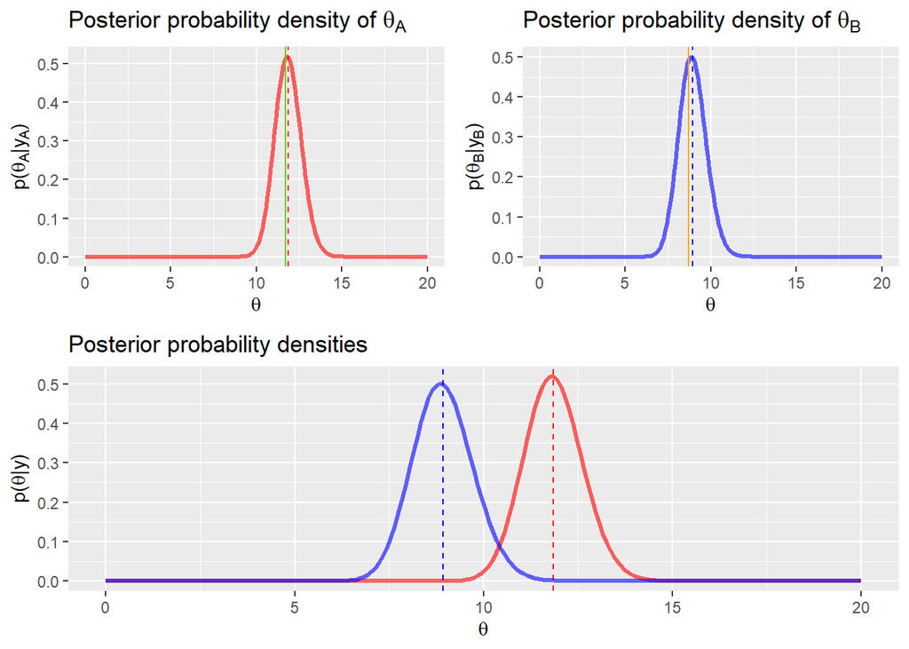

```r
#posterior density plots

post.data %>% ggplot() +
  geom_line(aes(x = gamma.values, y = post.values.a), col = "red", alpha = 0.6, size = 1.2) +
  geom_vline(xintercept = mean_a, col = "red", linetype = 2) +
  scale_color_discrete(guide = "none") -> p1

post.data %>% ggplot() +
  geom_line(aes(x = gamma.values, y = post.values.b), col = "blue", alpha = 0.6, size = 1.2) +
  geom_vline(xintercept = mean_b, col = "blue", linetype = 2) +
  scale_color_discrete(guide = "none") -> p2

p3 <- p1 +
  geom_line(aes(x = gamma.values, y = post.values.b), col = "blue", alpha = 0.6, size = 1.2) +
  geom_vline(xintercept = mean_b, col = "blue", linetype = 2) +
  xlab(expression(theta)) +
  ylab(expression(paste("p(", theta, "|", y, ")"))) +
  ggtitle("Posterior probability densities")

p1 <- p1 +
  geom_vline(xintercept = mean(y.a), col = "chartreuse3", linetype = 1) +
  xlab(expression(theta)) +
  ylab(expression(paste("p(", theta[A], "|", y[A], ")"))) +
  ggtitle(expression(paste("Posterior probability density of ", theta[A])))

p2 <- p2 +
  geom_vline(xintercept = mean(y.b), col = "orange", linetype = 1) +
  xlab(expression(theta)) +
  ylab(expression(paste("p(", theta[B], "|", y[B], ")"))) +
  ggtitle(expression(paste("Posterior probability density of ", theta[B])))

grid.arrange(arrangeGrob(p1, p2, ncol = 2), p3, nrow = 2)
```

Using the posterior distributions, the 95% quantile-based intervals are:

```r
#quantile intervals

quant.interval.a = qgamma(c(alpha / 2, 1 - alpha / 2), shape = a_n, rate = b_n)
quant.interval.b = qgamma(c(alpha / 2, 1 - alpha / 2), shape = c_n, rate = d_n)
```

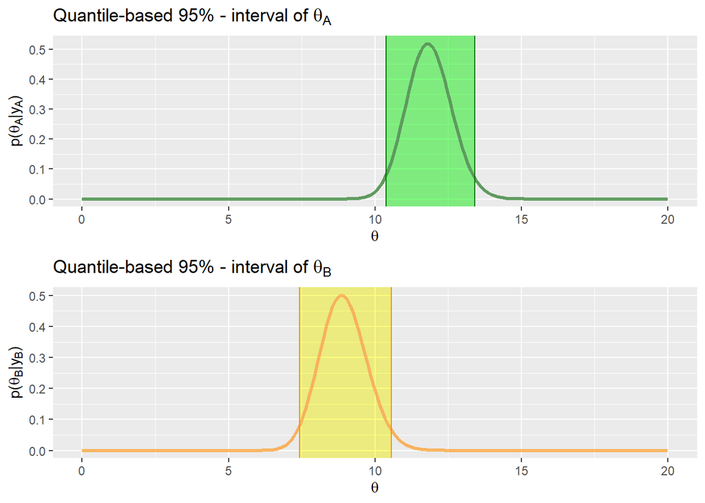

```r
#quantile-based intervals plots

post.data %>% ggplot() +
  geom_line(aes(x = gamma.values, y = post.values.a), col = "darkgreen", alpha = 0.6, size = 1.2) +
  geom_vline(xintercept = quant.interval.a[1], col = "darkgreen") +
  geom_vline(xintercept = quant.interval.a[2], col = "darkgreen") +
  geom_rect(aes(xmin = quant.interval.a[1], xmax = quant.interval.a[2], ymin = -Inf, ymax = Inf), fill = "green",
    alpha = 0.002) +
  xlab(expression(theta)) +
  ylab(expression(paste("p(", theta[A], "|", y[A], ")"))) +
  ggtitle(expression(paste("Quantile-based 95% - interval of ", theta[A]))) +
  scale_color_discrete(guide = "none") -> q1

post.data %>% ggplot() +
  geom_line(aes(x = gamma.values, y = post.values.b), col = "darkorange", alpha = 0.6, size = 1.2) +
  geom_vline(xintercept = quant.interval.b[1], col = "darkorange") +
  geom_vline(xintercept = quant.interval.b[2], col = "darkorange") +
  geom_rect(aes(xmin = quant.interval.b[1], xmax = quant.interval.b[2], ymin = -Inf, ymax = Inf), fill = "orange",
    alpha = 0.002) +
  xlab(expression(theta)) +
  ylab(expression(paste("p(", theta[B], "|", y[B], ")"))) +
  ggtitle(expression(paste("Quantile-based 95% - interval of ", theta[B]))) +
  scale_color_discrete(guide = "none") -> q2


grid.arrange(q1, q2, nrow = 2)
```

### Point b.

Suppose we now consider a new model, where the prior for $\theta_B$ is dependent on a parameter $n_0$ in the following way:
$$\begin{align*}
\theta_B \sim \text{Gamma}(12 \times n_0, n_0)
\end{align*}$$

Therefore the new posterior is the following:
$$\begin{align*}
\begin{array}{l}
Y_B \; | \; \theta_B \sim \text{Pois}(\theta_B) \\
\theta_B \sim \text{Gamma}(12 \times n_0, n_0)
\end{array} \hspace{0.3cm}
\theta_B \; | \; Y_B = \mathbf{y}_B \sim \text{Gamma}(12 \times n_0
+ \displaystyle \sum_{i = 1}^{n_B} y_{B, i} \;, n_0 + n_B)
\end{align*}$$

The posterior mean therefore depends on the parameter $n_0$ with the following evolution:

```r
mean.b = rep(0, 50)

n_0 = 1:50

for (i in n_0){
  a = 12 * i + sum(y.b)
  b = i + length(y.b)
  mean.b[i] = a / b
}

mean_varying <- data.frame(n_0, mean.b)
```

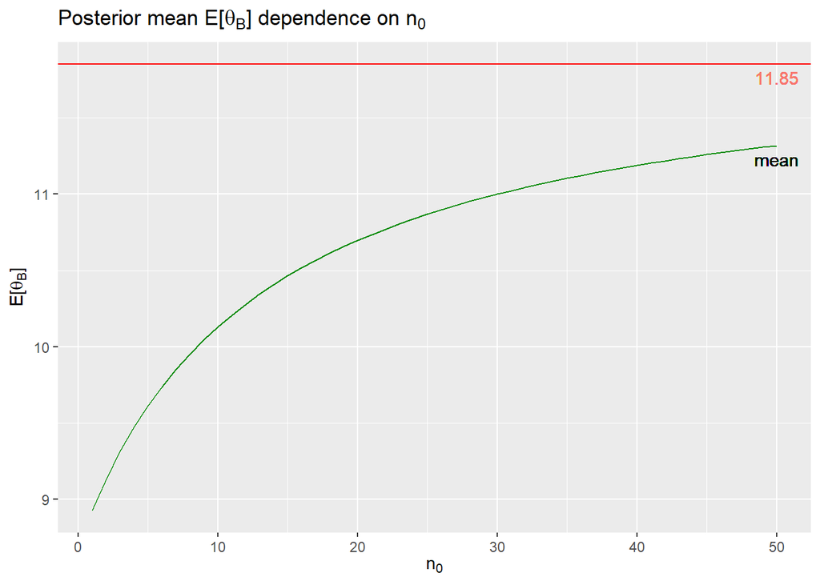

```r
mean_varying %>% ggplot(aes(x = n_0, y = mean.b)) +
  geom_line(col = "green4") +
  xlab(expression(n[0])) +
  ylab(expression(paste("E[", theta[B], "]"))) +
  ggtitle(expression(paste("Posterior mean ", "E[", theta[B], "]", " dependence on ", n[0]))) +
  geom_hline(yintercept = mean_a, col = "red") +
  scale_color_discrete(guide = "none") +
  geom_text(aes(50, mean_a, label = mean_a, vjust = +1.5, col = "red")) +
  geom_text(aes(50, mean.b[50], label = "mean", vjust = +1.5))
```

As we can observe, the more $n_0$ grows, the more the posterior mean of $\theta_B$ approaches that of $\theta_A$, as we can observe if we extend the interval of variation of $n_0$ itself:

```r
mean.b = rep(0, 200)

n_0 = 1:200

for (i in n_0){
  a = 12 * i + sum(y.b)
  b = i + length(y.b)
  mean.b[i] = a / b
}

mean_varying_2 <- data.frame(n_0, mean.b)
```

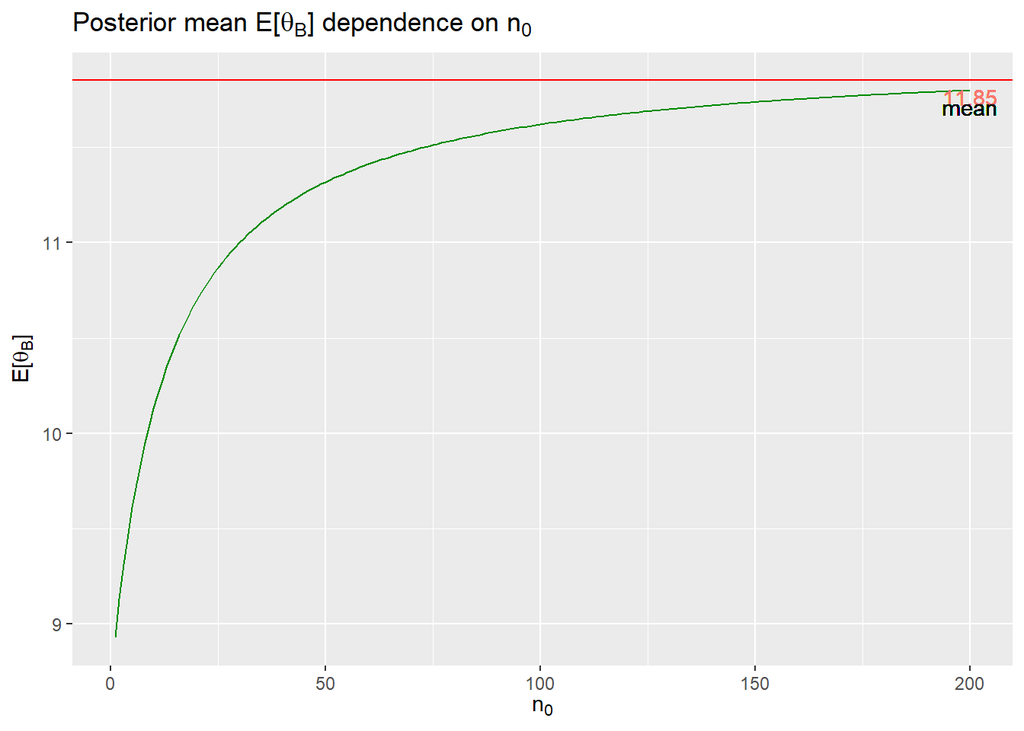

```r
mean_varying_2 %>% ggplot(aes(x = n_0, y = mean.b)) +
  geom_line(col = "green4") +
  xlab(expression(n[0])) +
  ylab(expression(paste("E[", theta[B], "]"))) +
  ggtitle(expression(paste("Posterior mean ", "E[", theta[B], "]", " dependence on ", n[0]))) +
  geom_hline(yintercept = mean_a, col = "red") +
  scale_color_discrete(guide = "none") +
  geom_text(aes(200, mean_a, label = mean_a, vjust =  +1.5, col = "red")) +
  geom_text(aes(200, mean.b[200], label = "mean", vjust = +1.5))
```

Therefore we can deduce that a large $n_0$ is required in order to have a posterior expectation close to that of $\theta_A$.

### Point c.

The independency assumption we have made in the model can be justified by the lack of information about the interrelations between the populations of mice. Even though we know that some form of dependency exists between the two parameters since the types of mice are related, we lack any additional information about the complexity of this relation, and therefore we can a priori assume the two parameters to be independent, since we need this to be able to compute the posterior distributions in a sensible way. Since the results seem to be consistent with this assumption, we justify the model through its own computability.

### Part 2: Tumor Counts Comparison

### Point d.

We can use the posterior distributions to obtain an approximation of $p \,( \, \theta_B < \theta_A \; | \; \mathbf{y}_A, \mathbf{y}_B)$ through Monte Carlo sampling. We start by obtaining that of the original distributions:

```r
s = 10000

#Monte Carlo estimate with original p(theta[B])
sample.a = rgamma(s, a_n, b_n)
sample.b = rgamma(s, c_n, d_n)

mc1 = sum(sample.a > sample.b) / s

sprintf("The Monte Carlo estimate given the original prior of theta[B] is: %f", mc1)
```

```
## [1] "The Monte Carlo estimate given the original prior of theta[B] is: 0.994900"
```

### Point e.

Then we proceed to obtain the one for the case of the parametrized posterior of $\theta_B$:

```r
#Monte Carlo estimate with varying p(theta[B])
n_0 = 1:50
mc2 = rep(0, 50)

for (i in n_0){
  a = 12 * i + sum(y.b)
  b = i + length(y.b)
  sample2.b = rgamma(s, a, b)
  mc2[i] = sum(sample.a > sample2.b) / s
}

mc1_varying <- data.frame(n_0, mc2)
```

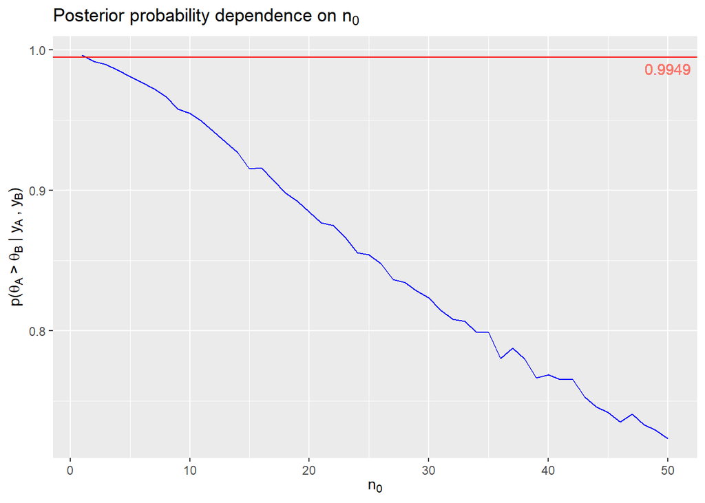

```r
mc1_varying %>% ggplot(aes(x = n_0, y = mc2)) +
  geom_line(col = "blue") +
  xlab(expression(n[0])) +
  ylab(expression(paste("p(", theta[A], " > ", theta[B], " | ", y[A], " , ", y[B], ")"))) +
  ggtitle(expression(paste("Posterior probability dependence on ", n[0]))) +
  geom_hline(yintercept = mc1, col = "red") +
  scale_color_discrete(guide = "none") +
  geom_text(aes(50, mc1, label = mc1, vjust = +1.5, col = "red"))
```

The resulting Monte Carlo estimate is very sensitive to the variation of the prior of $\theta_B$, since we have a relatively fast decay of the probability $p \,( \, \theta_B < \theta_A \; | \; \mathbf{y}_A, \mathbf{y}_B)$ with respect to the variation of the parameter $n_0$.

### Point f.

```r
#Monte Carlo estimate of the posterior predictive distribution (original theta[B])

y.post.a = rep(0, s)
y.post.b = rep(0, s)

for (i in 1:s){
  y.post.a[i] = rpois(1, sample.a[i])
  y.post.b[i] = rpois(1, sample.b[i])
}

mc3 = sum(y.post.a > y.post.b) / s
sprintf("The Monte Carlo estimate given the original prior of theta[B] is: %f", mc3)
```

```
## [1] "The Monte Carlo estimate given the original prior of theta[B] is: 0.703300"
```

```r
#Monte Carlo estimate of the posterior predictive distribution (varying theta[B])

mc4 = rep(0, 50)

for (i in 1:50){
  y.post2.b = rep(0, s)
  a = 12 * i + sum(y.b)
  b = i + length(y.b)
  sample2.b = rgamma(s, a, b)
  for (j in 1:s){
  y.post2.b[j] = rpois(1, sample2.b[j])
  }
  mc4[i] = sum(y.post.a > y.post2.b) / s
}

mc3_varying <- data.frame(n_0, mc4)
```

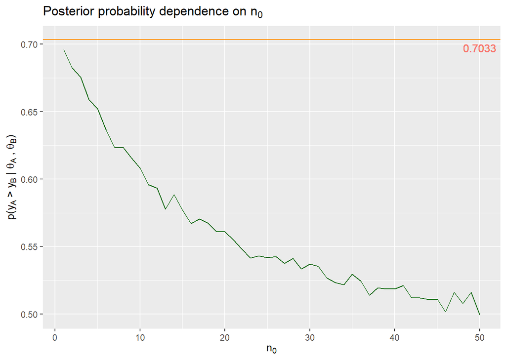

```r
mc3_varying %>% ggplot(aes(x = n_0, y = mc4)) +
  geom_line(col = "darkgreen") +
  xlab(expression(n[0])) +
  ylab(expression(paste("p(", y[A], " > ", y[B], " | ", theta[A], " , ", theta[B], ")"))) +
  ggtitle(expression(paste("Posterior probability dependence on ", n[0]))) +
  geom_hline(yintercept = mc3, col = "darkorange") +
  scale_color_discrete(guide = "none") +
  geom_text(aes(50, mc3, label = mc3, vjust = +1.5, col = "orange"))
```

### Part 3: Posterior predictive checks

Lastly one can investigate the adequacy of the Poisson model for the tumor count data in the following way.

### Point g.

First we generate posterior predictive datasets $\mathbf{y}^{(1)}_{A}, \dots, \mathbf{y}^{(1000)}_{A}$, where each $\mathbf{y}^{(s)}_{A}$ is a sample of size $n_A$ = 10 from the Poisson distribution with parameter $\theta^{(s)}_{A}$ and $\theta^{(s)}_{A}$ is itself a sample from the posterior distribution $p \, ( \, \theta_A \; | \; Y_A = \mathbf{y}_A)$, and $\mathbf{y}_A$ is the observed data.

```r
#generating the samples case theta[A]

K = 1000
sample.theta.a = rgamma(K, a_n, b_n)
t1 = rep(0, K)
for (i in 1:K){
  post.pred.a = rpois(10, sample.theta.a[i])
  t1[i] = sum(post.pred.a) / (10 * sd(post.pred.a))
}

t2 =  sum(y.a) / (10 * sd(y.a))

t.a <- data.frame(1:K, t1)

colors <- c("data mean" = "blue", "sample mean" = "red")
```

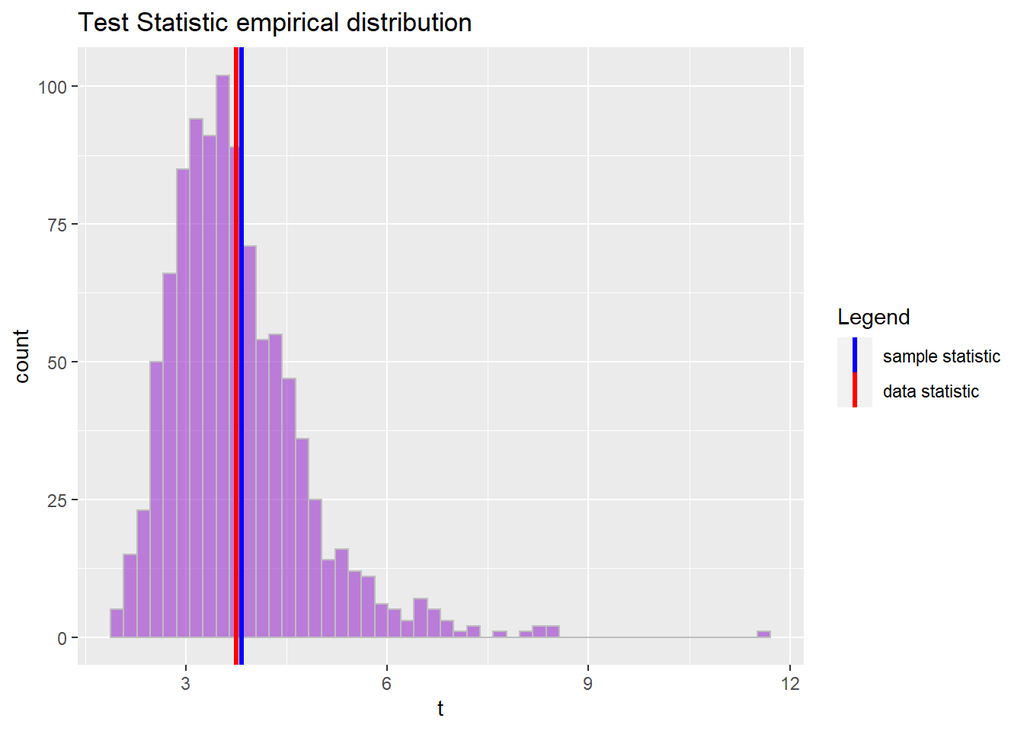

```r
t.a %>% ggplot() +
  geom_histogram(aes(t1), bins = 50, fill = "darkorchid", alpha = 0.6, col = "grey") +
  geom_vline(aes(xintercept = t2, col = "sample mean"), size = 1.2)  +
  geom_vline(aes(xintercept = mean(t1), col = "data mean"), size = 1.2) +
  xlab("t") +
  ggtitle("Test Statistic empirical distribution") +
  scale_color_manual(name = "Legend", values = c("sample mean" = "blue", "data mean" = "red"),
    labels = c("sample statistic", "data statistic"))
```

We can see that while the distribution is spread out, the expected value of the statistic is close to the one observed from the data, and the distribution itself is peaked around its mean value: this indicates that our original Poisson assumption seems to be corroborated by the data, and is therefore consistent with the observations.

### Point h.

We can repeat the same procedure with the second model, by generting posterior predictive datasets $\mathbf{y}^{(1)}_{B}, ...\mathbf{y}^{(1000)}_{B}$, where each $\mathbf{y}^{(s)}_{B}$ is a sample of size $n_B$ = 13 from the Poisson distribution with parameter $\theta^{(s)}_{B}$ and $\theta^{(s)}_{B}$ is itself a sample from the posterior distribution $p \, ( \, \theta_B \; | \; Y_B = \mathbf{y}_B)$, and $\mathbf{y}_B$ is the observed data.

```r
#generating the samples case theta[B]

K = 1000
sample.theta.b = rgamma(K, c_n, d_n)
t3 = rep(0, K)
for (i in 1:K){
  post.pred.b = rpois(13, sample.theta.b[i])
  t3[i] = sum(post.pred.a) / (13 * sd(post.pred.b))
}

t4 =  sum(y.a) / (13 * sd(y.a))

t.b <- data.frame(1:K, t3)
```

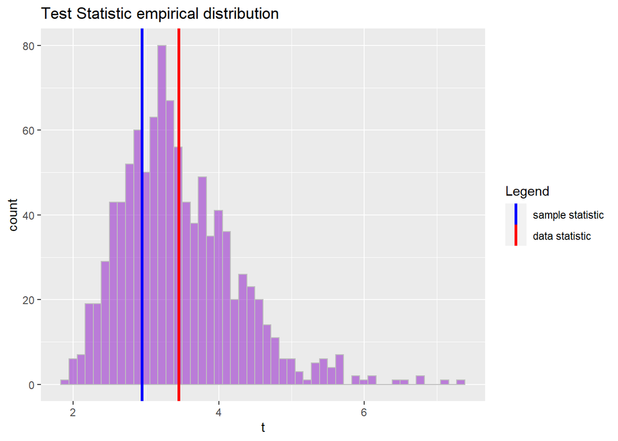

```r
t.b %>% ggplot() +
  geom_histogram(aes(t3), bins = 50, fill = "darkorchid", alpha = 0.6, col = "grey") +
  geom_vline(aes(xintercept = t4, col = "sample statistic"), size = 1.2) +
  geom_vline(aes(xintercept = mean(t3), col = "data statistic"), size = 1.2) +
  xlab("t") +
  ggtitle("Test Statistic empirical distribution") +
  scale_color_manual(name = "Legend", values = c("sample statistic" = "blue", "data statistic" = "red"),
    labels = c("sample statistic", "data statistic"))
```